# BVDE929_report

Marion Hardy

2023-03-16

# Introduction

Cells were treated with H2O2 (or ctrl) and proteins were digested, tagged with TMT and loaded onto the LC-MS/MS. Oxidized methionins were conserved.

We want to know if oxidization might have happened at ionization, in which case the retention time for a non-oxidized peptide should be the same as the one for an oxidized peptide.

We have 3 excel files

- PSMs
- PeptideGroups
- (ProteingGroups)

# Data clean up

```r
# Filtering out contaminants

dim(data)
```

```
## [1] 28033    49
```

```r
data =
  data %>%
  filter(Contaminant != "TRUE")

dim(data)
```

```
## [1] 27776    49
```

```r
# Reduce the number of rows to keep only the ones of interest

data = data[,c(3:5,9,10,16:23,29:44)]
colnames(data)
```

```
##  [1] "Annotated Sequence"
##  [2] "Modifications"
##  [3] "Contaminant"
##  [4] "# Proteins"
##  [5] "# PSMs"
##  [6] "Abundance Ratio: (F1, H2O2) / (F1, Non R)"
##  [7] "Abundance Ratio: (F2, H2O2) / (F2, Non R)"
##  [8] "Abundance Ratio Adj. P-Value: (F1, H2O2) / (F1, Non R)"
##  [9] "Abundance Ratio Adj. P-Value: (F2, H2O2) / (F2, Non R)"
## [10] "Abundances (Grouped): F1, H2O2"
## [11] "Abundances (Grouped): F1, Non R"
## [12] "Abundances (Grouped): F2, H2O2"
## [13] "Abundances (Grouped): F2, Non R"
## [14] "Found in Sample: [S1] F1: 126, Sample, H2O2"
## [15] "Found in Sample: [S4] F1: 127C, Sample, H2O2"
## [16] "Found in Sample: [S6] F1: 128C, Sample, H2O2"
## [17] "Found in Sample: [S8] F1: 129C, Sample, H2O2"
## [18] "Found in Sample: [S3] F1: 127N, Sample, Non R"
## [19] "Found in Sample: [S5] F1: 128N, Sample, Non R"
## [20] "Found in Sample: [S7] F1: 129N, Sample, Non R"
## [21] "Found in Sample: [S9] F1: 130N, Sample, Non R"
## [22] "Found in Sample: [S2] F2: 126, Sample, H2O2"
## [23] "Found in Sample: [S11] F2: 127C, Sample, H2O2"
## [24] "Found in Sample: [S13] F2: 128C, Sample, H2O2"
## [25] "Found in Sample: [S15] F2: 129C, Sample, H2O2"
## [26] "Found in Sample: [S10] F2: 127N, Sample, Non R"
## [27] "Found in Sample: [S12] F2: 128N, Sample, Non R"
## [28] "Found in Sample: [S14] F2: 129N, Sample, Non R"
## [29] "Found in Sample: [S16] F2: 130N, Sample, Non R"
```

```r
colnames(data)[10:13] = c("F1_H2O2","F1_ctrl","F2_H2O2","F2_ctrl")

# Filter out peptides which appear in <4 conditions

cols = sapply(data[14:29], grepl, pattern = "Not.*{2,}")
data = data[rowSums(cols) >= 3, ]

dim(data)
```

```
## [1] 20086    29
```

```r
# Filter out PSM <1

data =
  data %>%
  filter(!`# PSMs` < 1)
```

We have 7690 peptides which appeared in less than four of the samples and none that had PSM = 0.

# Analysis

## Frequency of peptide oxidation

```r
dim(pepox)
```

```
## [1] 1554   29
```

```r
head(pepox)
```

```
## # A tibble: 6 × 29
##   Annotated Se…¹ Modif…² Conta…³ # Pro…⁴ # PSM…⁵ Abund…⁶ Abund…⁷ Abund…⁸ Abund…⁹
##   <chr>          <chr>   <lgl>     <dbl>   <dbl>   <dbl>   <dbl>   <dbl>   <dbl>
## 1 [-].MAAAPAVCA… 1xDiox… FALSE         1       1      NA   NA         NA  NA
## 2 [-].MAAHVGSRC… 1xDiox… FALSE         1       1      NA   NA         NA  NA
## 3 [-].MAAVAVLRA… 1xOxid… FALSE         2       5      NA    1.12      NA   0.558
## 4 [-].MADAASPCS… 1xDiox… FALSE         1       1      NA   NA         NA  NA
## 5 [-].MAGVACLGK… 1xDiox… FALSE         2       2      NA    1.01      NA   1
## 6 [-].MAVEGGMK.… 1xOxid… FALSE         5       1      NA    1.61      NA   0.142
## # … with 20 more variables: F1_H2O2 <dbl>, F1_ctrl <dbl>, F2_H2O2 <dbl>,
## #   F2_ctrl <dbl>, `Found in Sample: [S1] F1: 126, Sample, H2O2` <chr>,
## #   `Found in Sample: [S4] F1: 127C, Sample, H2O2` <chr>,
## #   `Found in Sample: [S6] F1: 128C, Sample, H2O2` <chr>,
## #   `Found in Sample: [S8] F1: 129C, Sample, H2O2` <chr>,
## #   `Found in Sample: [S3] F1: 127N, Sample, Non R` <chr>,
## #   `Found in Sample: [S5] F1: 128N, Sample, Non R` <chr>, …
```

```r
dim(pepctrl)
```

```
## [1] 18532    29
```

```r
head(pepctrl)
```

```
## # A tibble: 6 × 29
##   Annotated Se…¹ Modif…² Conta…³ # Pro…⁴ # PSM…⁵ Abund…⁶ Abund…⁷ Abund…⁸ Abund…⁹
##   <chr>          <chr>   <lgl>     <dbl>   <dbl>   <dbl>   <dbl>   <dbl>   <dbl>
## 1 [-].IYFQLHR.[… 1xTMT6… FALSE         1       1      NA   0.934      NA       1
## 2 [-].MAAAAKPNN… 1xTMT6… FALSE         4       1      NA  NA          NA      NA
## 3 [-].MAAAAVAR.… 1xTMT6… FALSE         5       1      NA   0.988      NA       1
## 4 [-].MAAADGGGP… 1xTMT6… FALSE         2       1      NA   0.955      NA       1
## 5 [-].MAAATLTSK… 1xTMT6… FALSE         1       1      NA   1.04       NA       1
## 6 [-].MAADAEPLE… 1xCarb… FALSE         2       1      NA   1.08       NA       1
## # … with 20 more variables: F1_H2O2 <dbl>, F1_ctrl <dbl>, F2_H2O2 <dbl>,
## #   F2_ctrl <dbl>, `Found in Sample: [S1] F1: 126, Sample, H2O2` <chr>,
## #   `Found in Sample: [S4] F1: 127C, Sample, H2O2` <chr>,
## #   `Found in Sample: [S6] F1: 128C, Sample, H2O2` <chr>,
## #   `Found in Sample: [S8] F1: 129C, Sample, H2O2` <chr>,
## #   `Found in Sample: [S3] F1: 127N, Sample, Non R` <chr>,
## #   `Found in Sample: [S5] F1: 128N, Sample, Non R` <chr>, …
```

[output not shown]

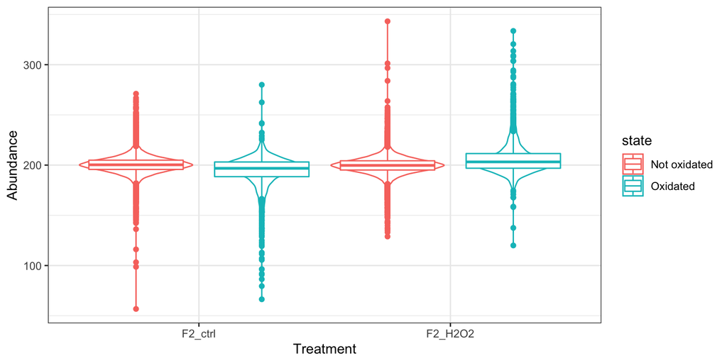

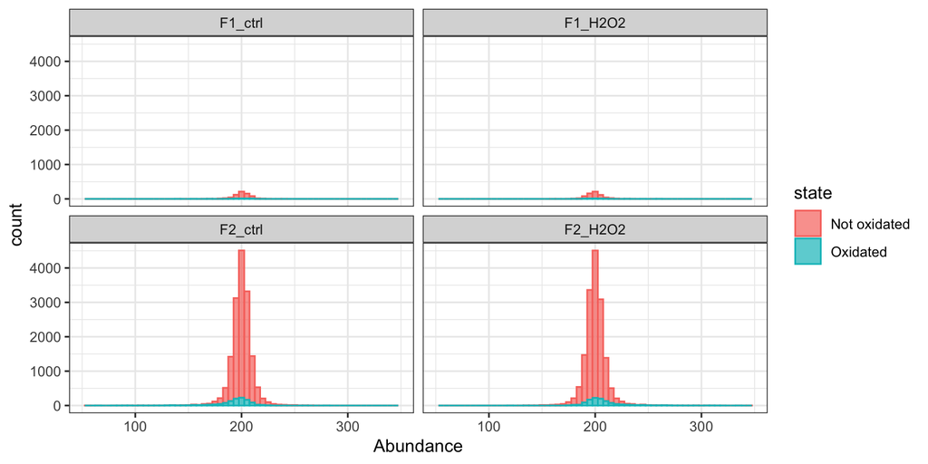

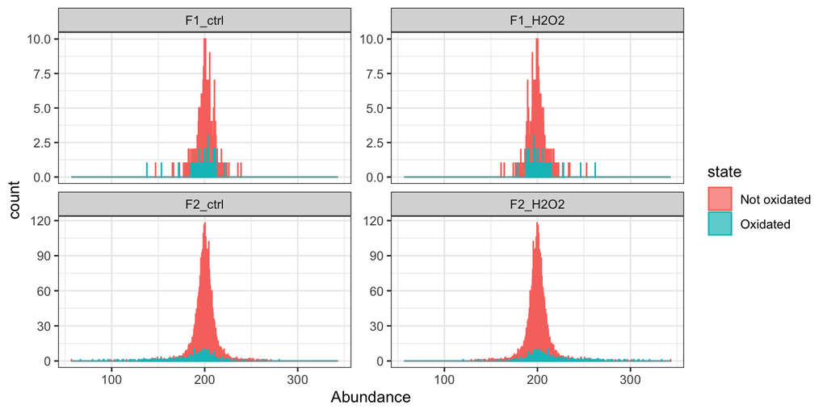

# Match the retention times to the right peptides

I merged the PSM file which contains the retention times with the PeptideGroup data I filtered before. Then I removed the unduplicated peptide sequences to be rid of any peptide not oxidized and unoxidized.

However, this filtering is not the best since it would keep two peptides oxidized in different places. But the idea is that the overall population comparison will compare peptides that were oxidized to peptide not oxidized.

```r
colnames(all)[36] = "Retention_time"
table(duplicated(all$`Annotated Sequence`))
```

```
##
## FALSE  TRUE
## 19765  3968
```

```r
all = all[duplicated(all$`Annotated Sequence`),]

lall =
  all %>%
  pivot_longer(c(10:13),
               names_to = "Treatment",
               values_to = "Abundance")
```

I removed the violin plots because I found a way to filter more stringently the peptides per condition and state.

## Filtering peptides

### Only the oxidated in H2O2 and the matching unoxidated in ctrl

Filtering peptides to keep only the peptides appearing in the two conditions and oxidated in H2O2 treatment and unoxidated in the ctrl treatment.

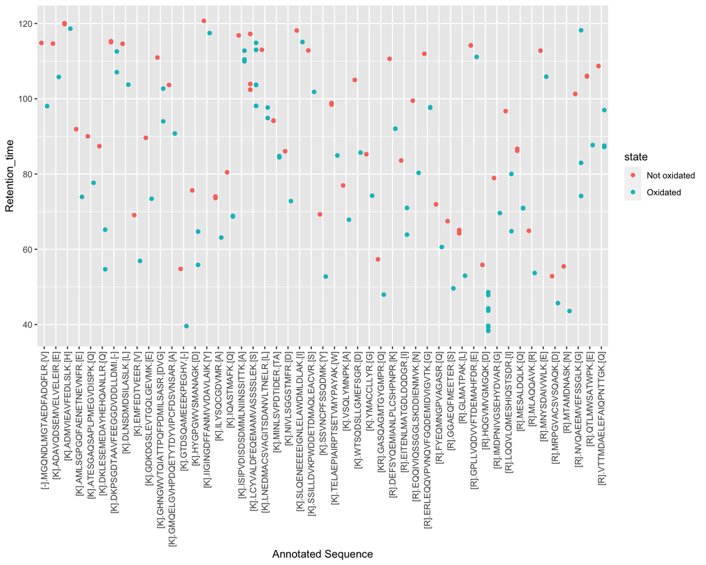

Il y a 49 peptides qui sont oxidés en H2O2 et non oxidés en ctrl mais on ne sait pas à quelle abondance ils sont! Il faut donc aller checker leur delta d’abondance et garder ceux qui sont oxidés et plus abondants en H2O2.